# Test

### The Machine Learning Model

#### Some considerations about the machine learning model that I could use for this multiclass classification problem.

- There are different classification algorithms that can be used for such a problem for example KNN, RandomForest or NaiveBayes
- They all have their advantages and disadvantages when it comes to computational times, performance etc..
- For this problem I will use a KNN which is a simple algorithm. Probably NaiveBayes or RandomForest are more appropriate for this problem and if time will allow me I will provide some implementations of those algorithms as well.

```python
# instantiate a KNN with an initial number of neighbors = 3.

knn = KNeighborsClassifier(n_neighbors=3)
```

```python
# make the fit i.e. the algorithm learns from the training data
knn.fit(X_train, y_train)
```

```
KNeighborsClassifier(n_neighbors=3)
```

```python
# make a prediction
yhat = knn.predict(X_test)
```

```python
yhat
```

```
array([-2, -1, -2,  0,  0,  0, -1,  2, -1, -2, -2,  0, -1, -2,  0,  1,  0,
        0,  0, -1,  0,  0, -2, -2,  0, -1, -2, -2,  2, -2, -2, -1, -2, -1,
       -1,  0, -1, -2, -2,  2, -1], dtype=int64)
```

```python
# measure accuracy
metrics.accuracy_score(yhat, y_test)
```

```
0.36585365853658536
```

```python
# The accuracy of KNN is very low
```

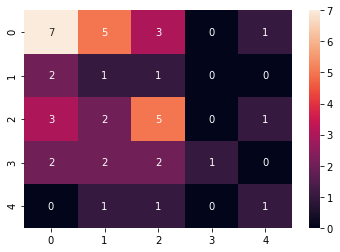

```python
# Compute and visualize the confusion metrics
cm = metrics.confusion_matrix(y_test, yhat)
sn.heatmap(cm, annot = True)
```

#### Compute the precision, recall and fscore for each class

```python
precision, recall, fscore, _ = score(y_test, yhat)
```

```python
# This will print the precisoin, recall and fscore for each class (in the columns)
print('precision: {}'.format(precision))
print('recall   : {}'.format(recall))
print('fscore   : {}'.format(fscore))
```

```
precision: [0.5        0.09090909 0.41666667 1.         0.33333333]
recall   : [0.4375     0.25       0.45454545 0.14285714 0.33333333]
fscore   : [0.46666667 0.13333333 0.43478261 0.25       0.33333333]
```

```python
#### Use a Multinomial Naive Bayes algorithm
```

```python
nb = MultinomialNB()
```

```python
nb.fit(X_train, y_train)
```

```
MultinomialNB()
```

```python
yhat_nb = nb.predict(X_test)
```

```python
### Compute precision and recall
```

```python
precision, recall, fscore, _ = score(y_test, yhat_nb)
```

```python
# This will print the precisoin, recall and fscore for each class (in the columns)
print('precision: {}'.format(precision))
print('recall   : {}'.format(recall))
print('fscore   : {}'.format(fscore))
```

```
precision: [0.75       0.33333333 0.34615385 0.         0.        ]
recall   : [0.5625     0.25       0.81818182 0.         0.        ]
fscore   : [0.64285714 0.28571429 0.48648649 0.         0.        ]
```

```python
# The Naive Bayes shows a better performance at least for the the first class.
```

```python
# If I had more time I would definetely have tried RandomForestClassifier.
# Hopefully RandomForestClassifier would have given a better result.
```